# Zambia Corridor City Scan

## Basic Information

### User Input Variables

scan-ID **2026-05-zambia_corridor** | GCS: **FALSE**  
City: **Zambia Corridor**  
Country: **NA**  
Manual benchmark cities: **None defined - using automatic detection from nearby countries**

### Benchmark Cities

Benchmark cities are selected as cities that are in neighboring countries and having a population of 50% to 150% of the focus city’s population, with addtional cities manually specified.

Benchmark cities

| Year | Population | Location | Country | Group | Area_km | Source | Method |
| --- | --- | --- | --- | --- | --- | --- | --- |

## WorldPop

### Population Growth

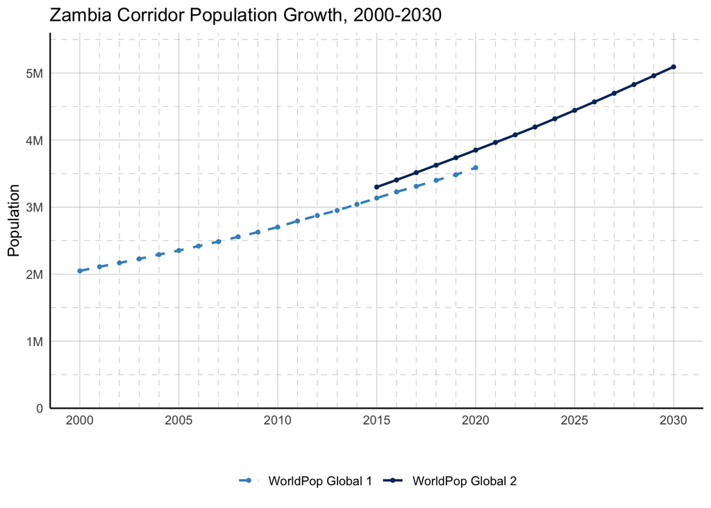

| Location | Source | year_1 | pop_1 | year_last | pop_last | span | change | change_pct | growth_rate |
| --- | --- | --- | --- | --- | --- | --- | --- | --- | --- |
| Zambia Corridor | WorldPop Global 1 | 2000 | 2048788 | 2020 | 3588115 | 20 | 1539327 | 75.1% | 2.8% |
| Zambia Corridor | WorldPop Global 2 | 2015 | 3299350 | 2030 | 5092090 | 15 | 1792740 | 54.3% | 2.9% |

**Zambia Corridor** (WorldPop Global 1)’s population grew by **75.1%** from **2,048,788** in **2000** to **3,588,115** in **2020** for an average annual growth rate of **2.8%**  
**Zambia Corridor** (WorldPop Global 2)’s population grew by **54.3%** from **3,299,350** in **2015** to **5,092,090** in **2030** for an average annual growth rate of **2.9%**  
**Yearly population** - sorted by absolute growth

| Year | Population | Location | Country | Group | Source | growth |
| --- | --- | --- | --- | --- | --- | --- |
| 2020 | 3588115 | Zambia Corridor | NA | Zambia Corridor | WorldPop Global 1 | 105245.47 |
| 2015 | 3134878 | Zambia Corridor | NA | Zambia Corridor | WorldPop Global 1 | 93251.53 |
| 2016 | 3226918 | Zambia Corridor | NA | Zambia Corridor | WorldPop Global 1 | 92039.97 |
| 2011 | 2793317 | Zambia Corridor | NA | Zambia Corridor | WorldPop Global 1 | 91322.29 |
| 2014 | 3041627 | Zambia Corridor | NA | Zambia Corridor | WorldPop Global 1 | 91273.82 |
| 2018 | 3398479 | Zambia Corridor | NA | Zambia Corridor | WorldPop Global 1 | 88144.05 |
| 2019 | 3482869 | Zambia Corridor | NA | Zambia Corridor | WorldPop Global 1 | 84390.72 |
| 2017 | 3310335 | Zambia Corridor | NA | Zambia Corridor | WorldPop Global 1 | 83416.38 |
| 2012 | 2874220 | Zambia Corridor | NA | Zambia Corridor | WorldPop Global 1 | 80902.71 |
| 2013 | 2950353 | Zambia Corridor | NA | Zambia Corridor | WorldPop Global 1 | 76132.98 |

[output cut: 27 more lines]

**Yearly population** - sorted by percentage growth

| Year | Population | Location | Country | Group | Source | growth_pct |
| --- | --- | --- | --- | --- | --- | --- |
| 2011 | 2793317 | Zambia Corridor | NA | Zambia Corridor | WorldPop Global 1 | 0.03379810 |
| 2014 | 3041627 | Zambia Corridor | NA | Zambia Corridor | WorldPop Global 1 | 0.03093658 |
| 2015 | 3134878 | Zambia Corridor | NA | Zambia Corridor | WorldPop Global 1 | 0.03065844 |
| 2001 | 2110713 | Zambia Corridor | NA | Zambia Corridor | WorldPop Global 1 | 0.03022510 |
| 2020 | 3588115 | Zambia Corridor | NA | Zambia Corridor | WorldPop Global 1 | 0.03021803 |
| 2016 | 3226918 | Zambia Corridor | NA | Zambia Corridor | WorldPop Global 1 | 0.02935998 |
| 2004 | 2292484 | Zambia Corridor | NA | Zambia Corridor | WorldPop Global 1 | 0.02914858 |
| 2012 | 2874220 | Zambia Corridor | NA | Zambia Corridor | WorldPop Global 1 | 0.02896295 |
| 2008 | 2556860 | Zambia Corridor | NA | Zambia Corridor | WorldPop Global 1 | 0.02880668 |
| 2010 | 2701995 | Zambia Corridor | NA | Zambia Corridor | WorldPop Global 1 | 0.02855545 |

[output cut: 27 more lines]

### WorldPop Global 1 (2000-2020)

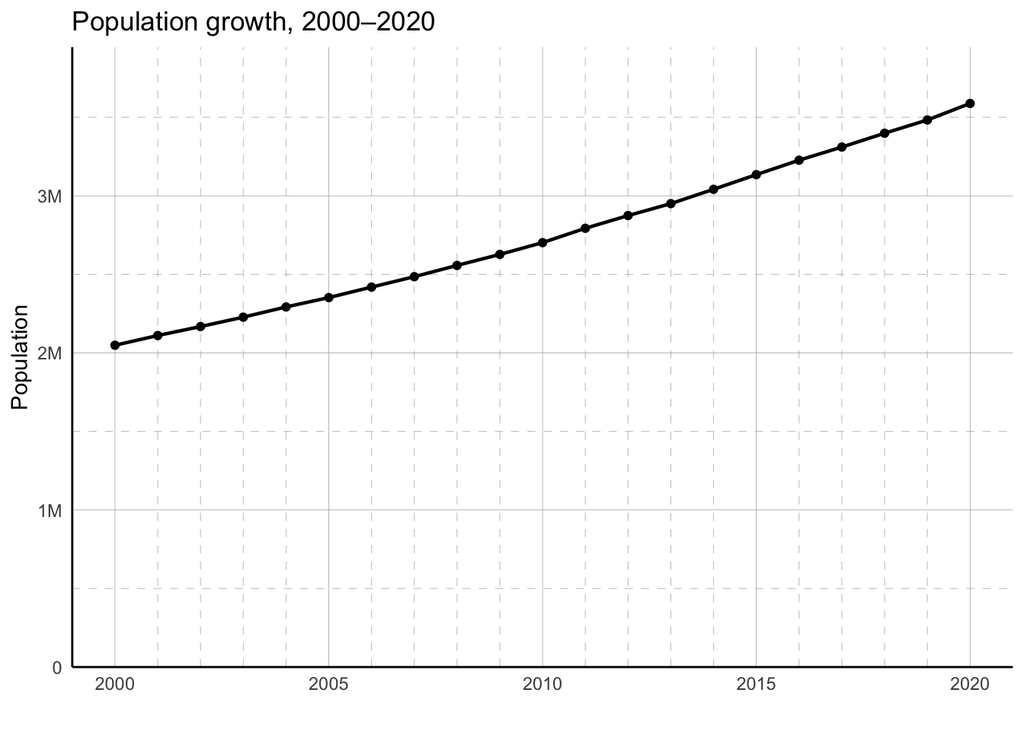

| Year | Population | Source |
| --- | --- | --- |
| 2000 | 2048788 | WorldPop Global 1 |
| 2001 | 2110713 | WorldPop Global 1 |
| 2002 | 2167789 | WorldPop Global 1 |
| 2003 | 2227554 | WorldPop Global 1 |
| 2004 | 2292484 | WorldPop Global 1 |
| 2005 | 2352149 | WorldPop Global 1 |
| 2006 | 2418995 | WorldPop Global 1 |
| 2007 | 2485268 | WorldPop Global 1 |
| 2008 | 2556860 | WorldPop Global 1 |
| 2009 | 2626980 | WorldPop Global 1 |

[output cut: 11 more lines]

### WorldPop Global 2 (2015-2030)

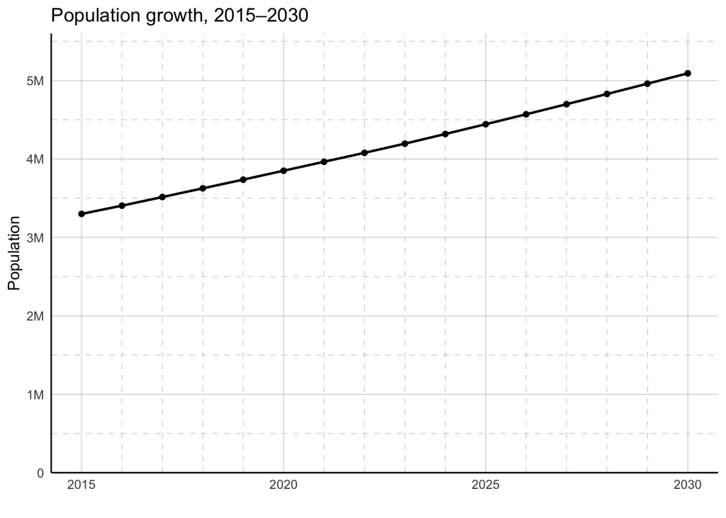

| Year | Population | Source |
| --- | --- | --- |
| 2015 | 3299350 | WorldPop Global 2 |
| 2016 | 3404294 | WorldPop Global 2 |
| 2017 | 3514496 | WorldPop Global 2 |
| 2018 | 3625469 | WorldPop Global 2 |
| 2019 | 3736367 | WorldPop Global 2 |
| 2020 | 3849998 | WorldPop Global 2 |
| 2021 | 3964074 | WorldPop Global 2 |
| 2022 | 4078113 | WorldPop Global 2 |
| 2023 | 4194875 | WorldPop Global 2 |
| 2024 | 4318145 | WorldPop Global 2 |

[output cut: 6 more lines]

### Population Density Distribution

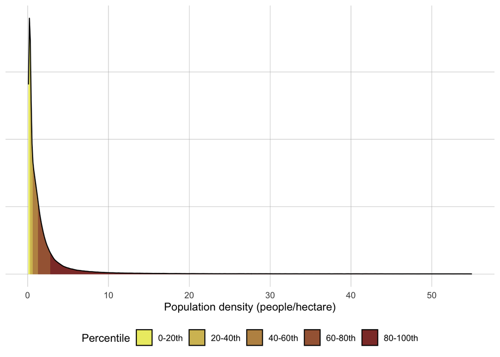

### Population Density

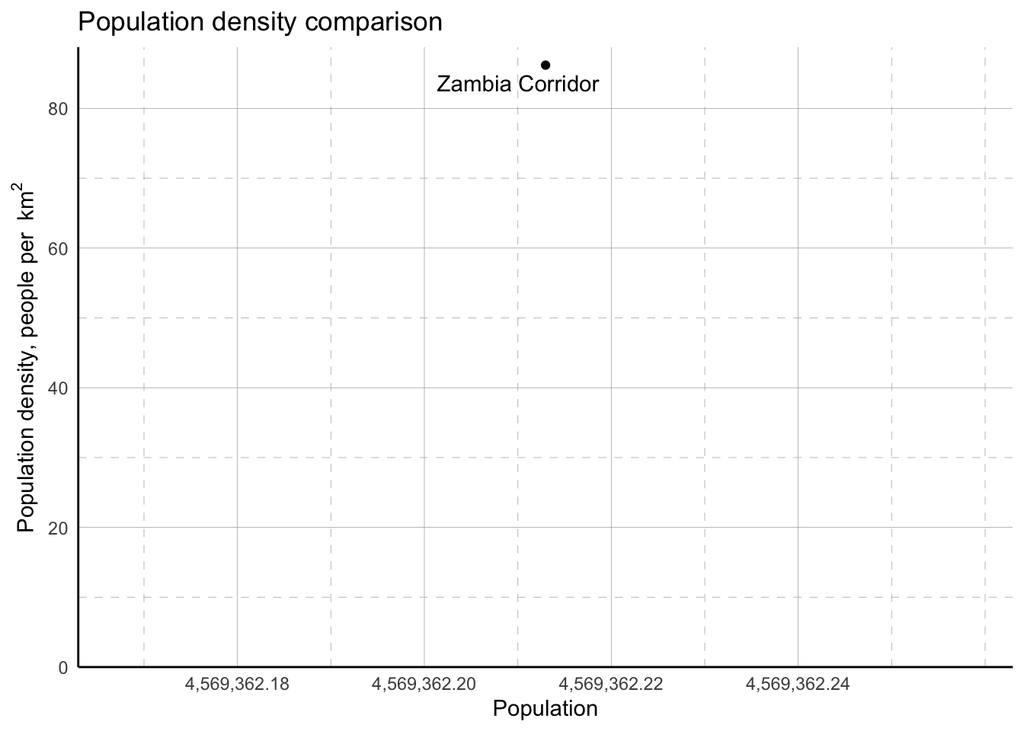

| Year | Population | Location | Country | Group | Area_km | Source | Method | Density |
| --- | --- | --- | --- | --- | --- | --- | --- | --- |
| 2026 | 4569362 | Zambia Corridor | NA | Zambia Corridor | 53012.42 | WorldPop Global 2 | WorldPop Global2 | 86.19418 |

### Benchmark Cities Population (WorldPop Global 1)

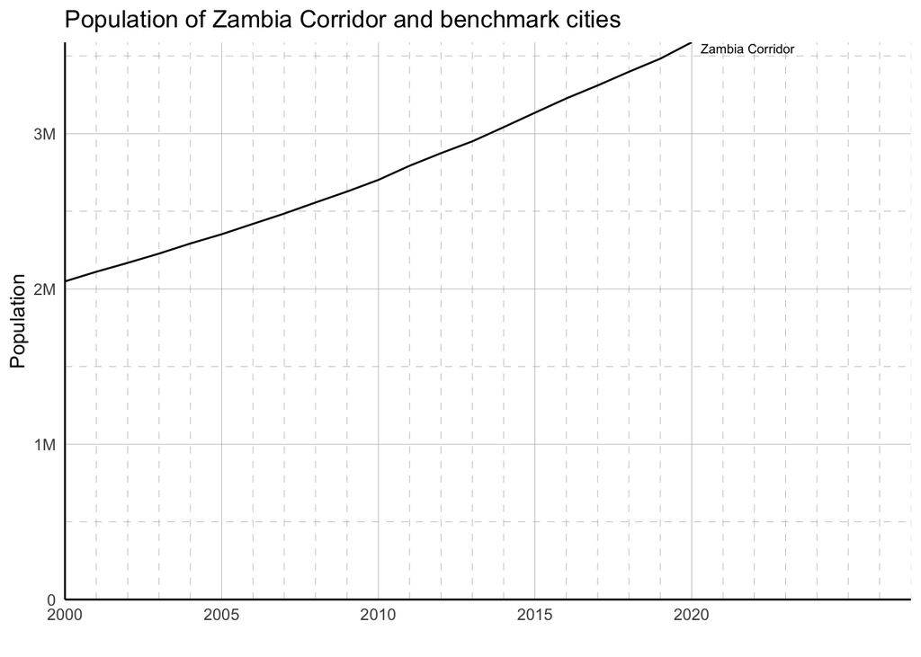

| Group | Location | Year | Population | Source |
| --- | --- | --- | --- | --- |
| Zambia Corridor | Zambia Corridor | 2020 | 3588115 | WorldPop Global 1 |

### Benchmark Cities Population (WorldPop Global 2)

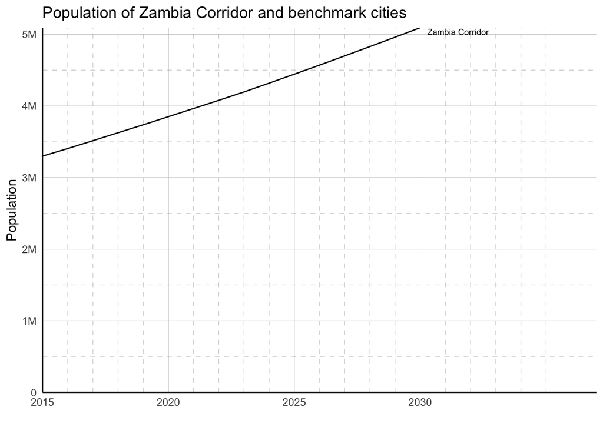

| Group | Location | Year | Population | Source |
| --- | --- | --- | --- | --- |
| Zambia Corridor | Zambia Corridor | 2026 | 4569362 | WorldPop Global 2 |

## Demographics

### Age-Sex Distribution

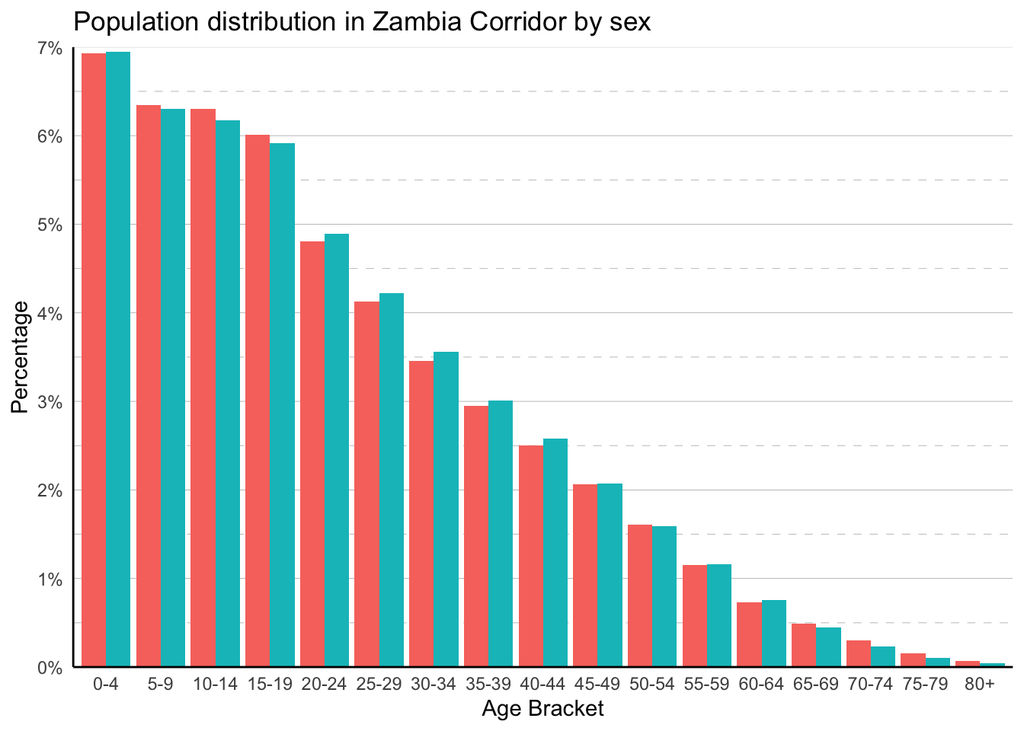

| Age_Bracket | Sex | Count | Percentage | Sexed_Percent | Sexed_Percent_cum |
| --- | --- | --- | --- | --- | --- |
| 0-4 | Female | 316470.539 | 0.0692899909 | 0.1385753478 | 0.1385753 |
| 0-4 | Male | 317176.312 | 0.0694445173 | 0.1388936792 | 0.1388937 |
| 5-9 | Female | 289617.969 | 0.0634107253 | 0.1268172098 | 0.2653926 |
| 5-9 | Male | 287663.156 | 0.0629827268 | 0.1259696660 | 0.2648633 |
| 10-14 | Female | 287889.000 | 0.0630321744 | 0.1260601332 | 0.3914527 |
| 10-14 | Male | 282120.312 | 0.0617691427 | 0.1235424168 | 0.3884058 |
| 15-19 | Female | 274575.656 | 0.0601172696 | 0.1202305187 | 0.5116832 |
| 15-19 | Male | 270142.812 | 0.0591467158 | 0.1182973875 | 0.5067031 |
| 20-24 | Female | 219548.109 | 0.0480692028 | 0.0961351907 | 0.6078184 |
| 20-24 | Male | 223604.797 | 0.0489573987 | 0.0979180718 | 0.6046212 |

[output cut: 24 more lines]

### Age Distribution

| Age_Bracket | Percentage | cumpct |
| --- | --- | --- |
| 0-4 | 0.138734508 | 0.1387345 |
| 5-9 | 0.126393452 | 0.2651280 |
| 10-14 | 0.124801317 | 0.3899293 |
| 15-19 | 0.119263985 | 0.5091933 |
| 20-24 | 0.097026601 | 0.6062199 |
| 25-29 | 0.083457167 | 0.6896770 |
| 30-34 | 0.070151176 | 0.7598282 |
| 35-39 | 0.059546375 | 0.8193746 |
| 40-44 | 0.050803126 | 0.8701777 |
| 45-49 | 0.041340799 | 0.9115185 |

[output cut: 7 more lines]

### Demographic Indicators

under5: 14%  
youth (15-24): 22%  
working_age (15-64): 59%  
elderly (60+): 3%  
reproductive_age, percent of women (15-50): 52%  
sex_ratio: 99.99 males to 100 females

## Relative Wealth Index

### Standardized RWI Distribution

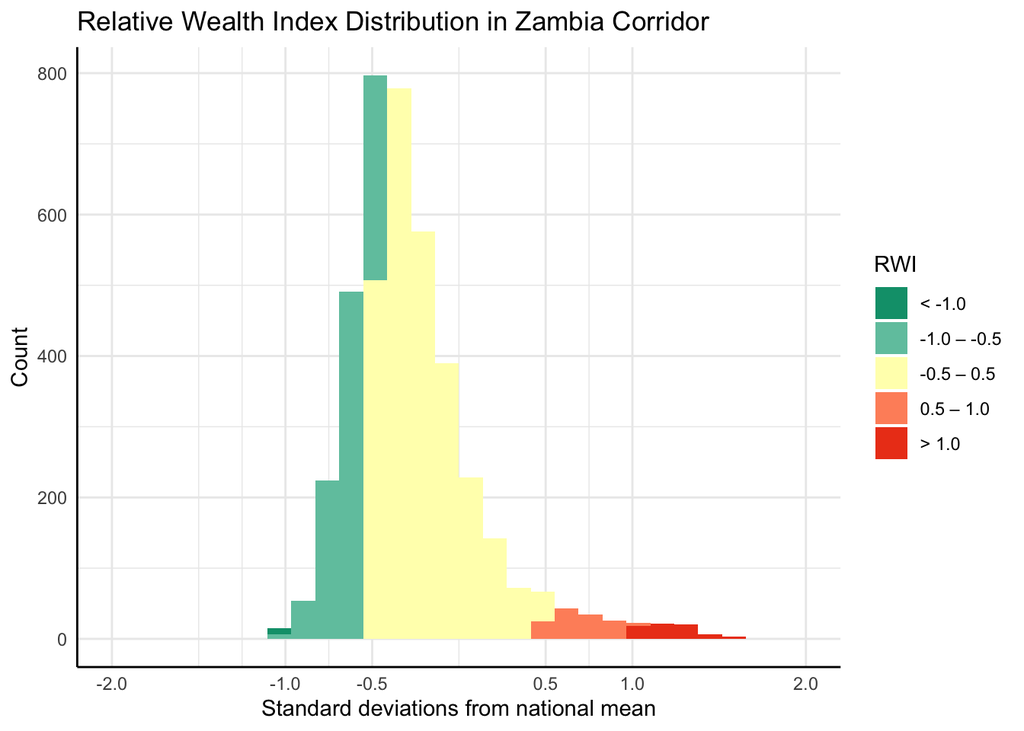

**-1.09** to **1.6** (mean: **-0.27**)  
**4013** grid cells in AOI

| bin | count | percentage |
| --- | --- | --- |
| < -1.0 | 9 | 0.21 |
| -1.0 – -0.5 | 1065 | 26.34 |
| -0.5 – 0.5 | 2735 | 68.29 |
| 0.5 – 1.0 | 133 | 3.35 |
| > 1.0 | 71 | 1.82 |

### City-Relative RWI Distribution

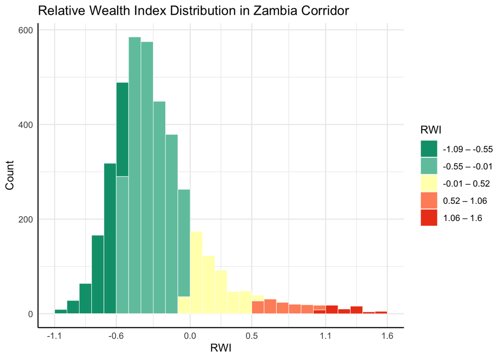

| bin | count | percentage |
| --- | --- | --- |
| -1.09 – -0.55 | 784 | 19.32 |
| -0.55 – -0.01 | 2505 | 62.41 |
| -0.01 – 0.52 | 532 | 13.41 |
| 0.52 – 1.06 | 131 | 3.30 |
| 1.06 – 1.60 | 61 | 1.56 |

## Urban Built-up Area

### WSF Evolution

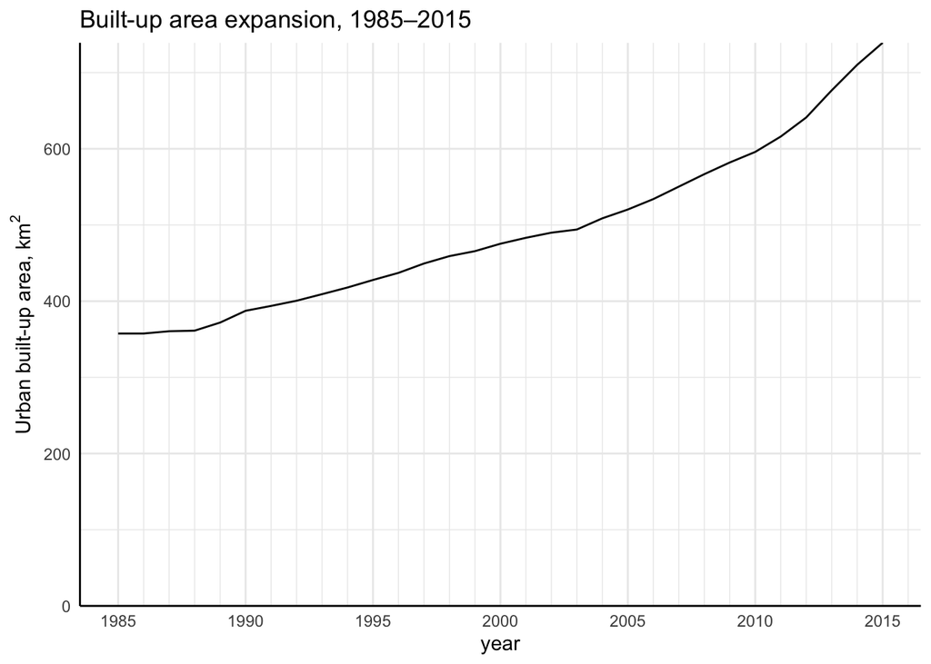

The city’s built-up area grew from **357.55** km² in 1985 to **739.18** in **2015** for **106.73**% growth

| year | cumulative_sq_km | growth_pct | growth_km2 |
| --- | --- | --- | --- |
| 1985 | 357.5538 | NA | NA |
| 1986 | 357.5538 | 0.000000000 | 0.0000000 |
| 1987 | 360.5345 | 0.008336434 | 2.9807234 |
| 1988 | 361.3141 | 0.002162356 | 0.7796038 |
| 1989 | 371.9263 | 0.029371076 | 10.6121843 |
| 1990 | 387.3842 | 0.041561775 | 15.4579171 |
| 1991 | 393.7618 | 0.016463176 | 6.3775746 |
| 1992 | 400.5824 | 0.017321769 | 6.8206505 |
| 1993 | 409.1829 | 0.021469890 | 8.6004607 |
| 1994 | 417.9535 | 0.021434397 | 8.7705887 |

[output cut: 21 more lines]

### WSF Tracker

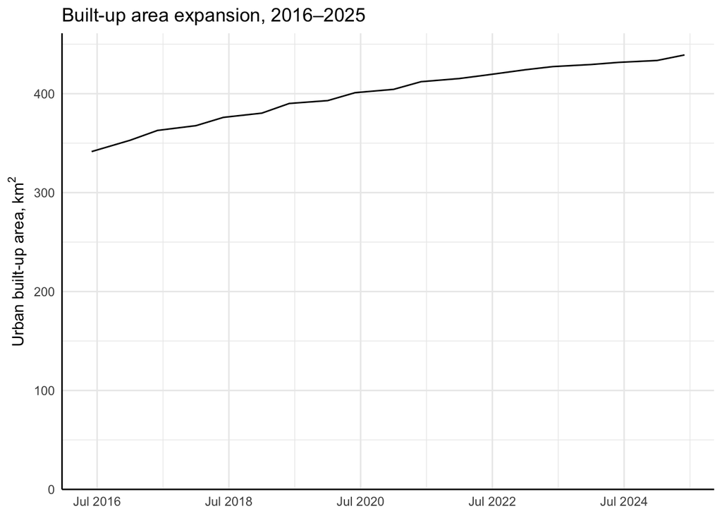

The city’s built-up area grew from **341.5** km² in **Jun 2016** to **439.16** in **Jun 2025** for **28.6**% growth

| year | month | cumulative_sq_km | date | growth_pct | growth_km2 |
| --- | --- | --- | --- | --- | --- |
| 2016 | 6 | 341.4960 | Jun 2016 | NA | NA |
| 2017 | 1 | 352.9172 | Jan 2017 | 0.033444602 | 11.421199 |
| 2017 | 6 | 362.8722 | Jun 2017 | 0.028207686 | 9.954979 |
| 2018 | 1 | 367.6854 | Jan 2018 | 0.013264058 | 4.813158 |
| 2018 | 6 | 376.0586 | Jun 2018 | 0.022772914 | 8.373267 |
| 2019 | 1 | 380.3419 | Jan 2019 | 0.011389957 | 4.283292 |
| 2019 | 6 | 390.1237 | Jun 2019 | 0.025718327 | 9.781758 |
| 2020 | 1 | 393.0091 | Jan 2020 | 0.007396242 | 2.885449 |
| 2020 | 6 | 401.0356 | Jun 2020 | 0.020423027 | 8.026436 |
| 2021 | 1 | 404.3796 | Jan 2021 | 0.008338387 | 3.343990 |

[output cut: 9 more lines]

### WSF Harmonized

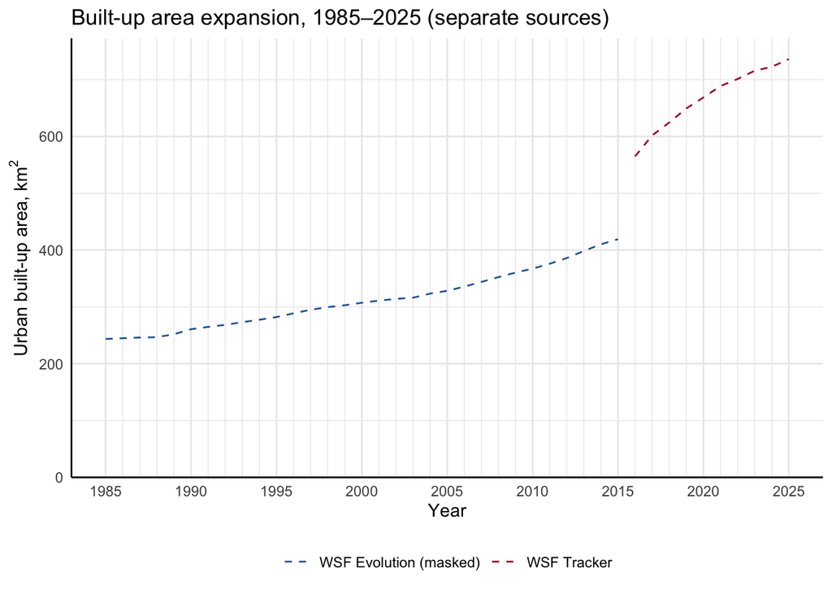

The city’s built-up area grew from **273.15** km² in 1985 to **735.98** in **2025** for **169.44**% growth

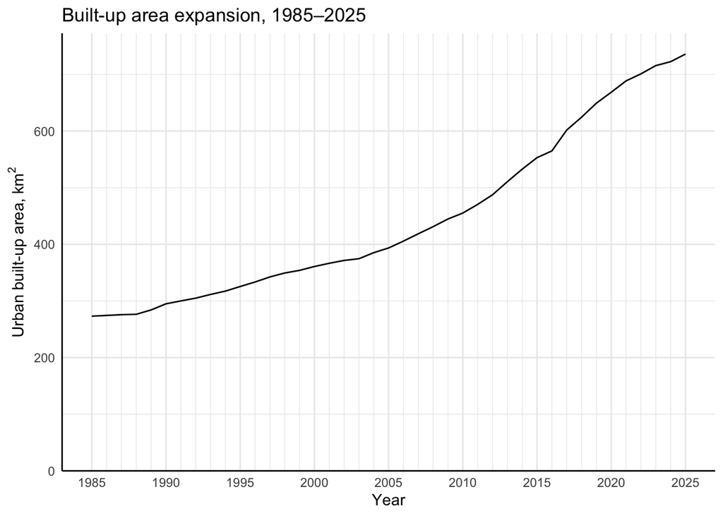

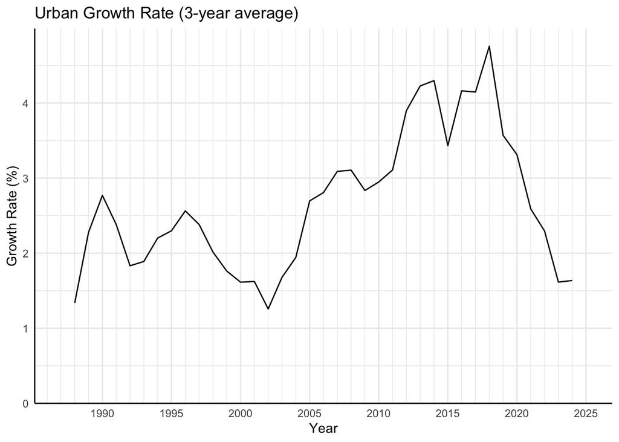

| year | cumulative_sq_km | source | growth_percentage |
| --- | --- | --- | --- |
| 1985 | 348.590 | WSF Evolution | NA |
| 1987 | 351.553 | WSF Evolution | 0.850 |
| 1988 | 352.307 | WSF Evolution | 0.215 |
| 1989 | 361.994 | WSF Evolution | 2.750 |
| 1990 | 376.686 | WSF Evolution | 4.059 |
| 1991 | 382.904 | WSF Evolution | 1.651 |
| 1992 | 389.529 | WSF Evolution | 1.730 |
| 1993 | 397.855 | WSF Evolution | 2.137 |
| 1994 | 405.727 | WSF Evolution | 1.979 |
| 1995 | 414.931 | WSF Evolution | 2.268 |

[output cut: 100 more lines]

## Land Cover

| Land Cover Type | Pixel Count | Percent |
| --- | --- | --- |
| Tree cover | 17527007 | 7.891817e-01 |
| Grassland | 3763756 | 1.694692e-01 |
| Shrubland | 794032 | 3.575257e-02 |
| Cropland | 107423 | 4.836894e-03 |
| Herbaceous wetland | 7890 | 3.552600e-04 |
| Built-up | 5019 | 2.259886e-04 |
| Permanent water bodies | 1532 | 6.898077e-05 |
| Bare / sparse vegetation | 1316 | 5.925502e-05 |
| Snow and ice | 1114 | 5.015964e-05 |

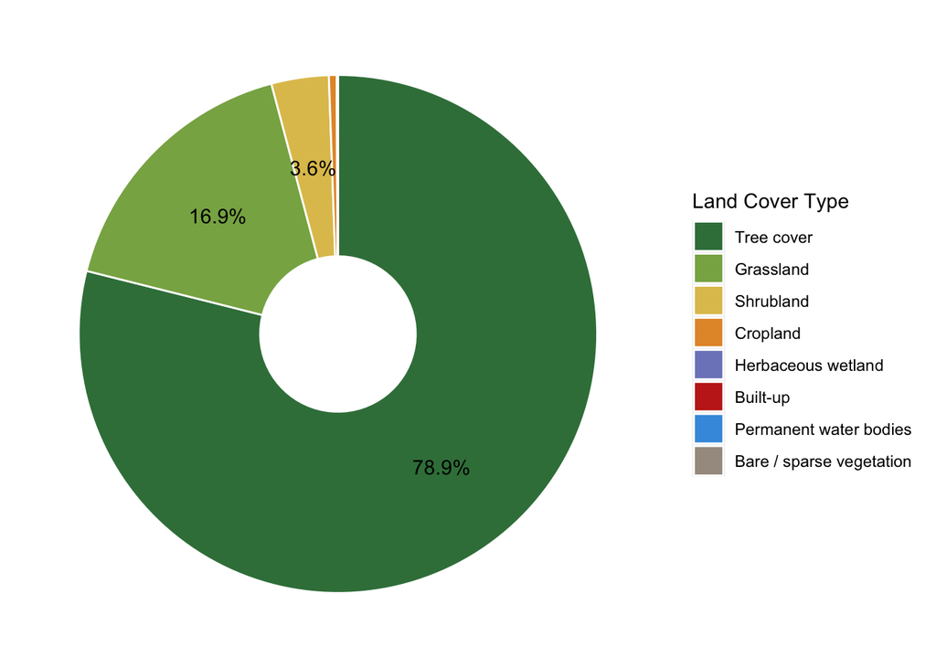

**Tree cover** comprises the majority of land in the **Zambia Corridor** area of interest (**78.9%**).  
The next largest land classes are **Grassland** (**16.9%**) and **Shrubland** (**3.6%**)

## Elevation

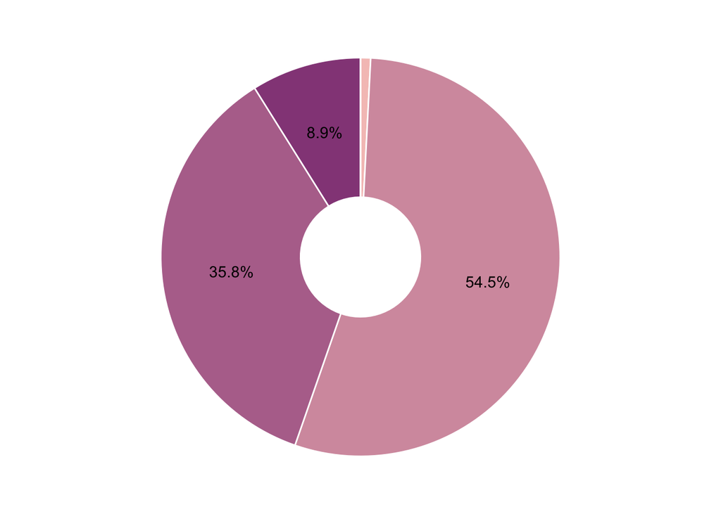

| Bin | Count | percent |
| --- | --- | --- |
| 1040-1160 | 682224 | 8.175233e-03 |
| 1160-1300 | 45484148 | 5.450461e-01 |
| 1300-1420 | 29858232 | 3.577974e-01 |
| 1420-1560 | 7424341 | 8.896743e-02 |
| 1560-1680 | 1153 | 1.381664e-05 |

## Slope

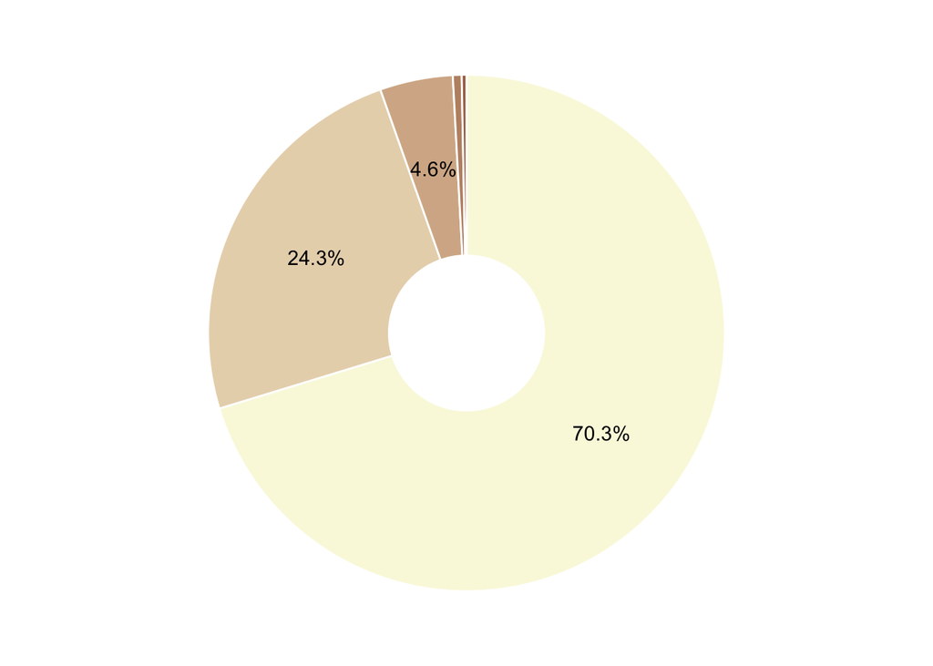

| Bin | Count | percent | Percent | Slope | UpperRange |
| --- | --- | --- | --- | --- | --- |
| 0-2 | 58640803 | 0.702760266 | 70% | 0 | 2 |
| 2-5 | 20287747 | 0.243131433 | 24% | 2 | 5 |
| 5-10 | 3807851 | 0.045633863 | 5% | 5 | 10 |
| 10-20 | 459147 | 0.005502487 | 1% | 10 | 20 |
| 20-90 | 247990 | 0.002971950 | 0% | 20 | 90 |